# Introduction to R Markdown

Nov 1<sup>st</sup>, 2017

## Outline

- What and Why
- Getting started
  - Syntax and basic elements
- Hands-on
  - Using code to produce output
- Show and tell

## What and why?

## What is this?

- Markdown is:
  - a lightweight markup language
  - easy-to-read, easy-to-write plain text that gets converted into HTML
- R Markdown is:
  - The above + R code embedded to create graphs, tables, values… any type of R output
- `knitr`, which is an R package, transforms *.Rmd into *.md, which is then processed by `pandoc`

## Keep in mind

### *"But remember, Markdown was designed for HTML, and LaTeX was for PDF and related output formats."*

Yihui Xie

- See Yihui's discussion on [Markdown vs. LaTeX](https://yihui.name/en/2013/10/markdown-or-latex/)

## Why?

- It is great for research
  - Keeps everything together (analysis, references, text, data…)
  - Easier to iterate over your work (*i.e.* easier to incorporate suggestions by Reviewer #2)
- It fosters reproducibility

## Getting started (just text)

## New Rmd document and types of output

- Slides
  - ioslides
  - slidy presentations
  - beamer*
- **HTML**
  - HTML notebook
- PDF
- Word
- Shiny (interactive documents)
  - Document
  - Presentation

## YAML

- Set of `key:` and `value` pairs
- Contains variables/parameters passed to `knitr` and `pandoc` to control output
- The default one looks like this:

```
---
title: "Introduction to R Markdown"
author: "Villaseñor-Derbez, J.C."
date: "November 1, 2017"
output: ioslides_presentation
---
```

## YAML

- You can also specify many other things:
- `fig_caption: yes` adds figure captions from chunks
- `toc: yes` adds a table of contents
- `subtitle:"Fancy subtitle"` adds a subtitle
- `bibliography: references.bib` specifies where to look for BibTeX entries
- `csl: plos.csl` specifies citation format (in this case, PLoS ONE's)

See [options for HTML](http://rmarkdown.rstudio.com/html_document_format.html) and [options for PDF](http://rmarkdown.rstudio.com/pdf_document_format.html) output

## Basic syntax

- Use `#` to indicate headers
- `*single asterisks*` give me *single asterisks*
- `**double asterisks**` give me **double asterisks**
- `m s^-2^` is then m s<sup>-2</sup>
- You can write LaTeX equations by wrapping an expression in `$`:
  - `$E = mC^2$` is \(E = mC^2\)
- Write Greek letters with `$\letter$`:
  - `$\beta$` gives you \(\beta\)
- Same for fancier equations:
  - `$$\hat{Y} = \sum_{i = 1}^N\frac{\beta_a^4}{\phi \times \Omega} + \beta_b$$` is just: \[\hat{Y} = \sum_{i = 1}^N\frac{\beta_a^4}{\phi \times \Omega} + \beta_b\]

## Basic syntax: bullets

- Bullets can be specified by -, +, or *

This:

```
* Item 1
* Item 2
    + Item 2a
    + Item 2b
```

Gives:

- Item 1
- Item 2
  - Item 2a
  - Item 2b

## Basic synax: numbered bullets

This

```
1. Item 1
2. Item 2
3. Item 3
    + Item 3a
    + Item 3b
```

Gives:

1. Item 1
2. Item 2
3. Item 3
   - Item 3a
   - Item 3b

## Links and Images

- Specify a link: `[go to google](www.google.com)`
- and see go to google
- You can insert images saved on your computer, or from the web:
  - image: `![](Img/RStudio-Ball.png)`

[figure not shown]

## Hands-on

## Code chunks and in-line code

- `There were "r nrow(mtcars)" cars studied`
- There were 32 cars studied
- Used to isolate plain text from code
- Allow you to execute R, Python, Rcpp, SQL, and Stan within your file
- Use `Ctrl` + `Alt` + `I` (Windows) `Cmd` + `Alt` + `I` (Mac) to insert
- Always name your chunks!

## References

You need:

- A BibTeX file (provided in the CourseMaterials folder)
- Specify `bibliography:` and `csl:` in the header
- That's it…

```
---
bibliography: references.bib
csl: Citation_styles/ieee.csl
---
```

"A tidy dataset has one column per variable" `[@wickham_2014]`

"A tidy dataset has one column per variable" [1]

**References**

[1] H. Wickham, “Tidy data,” *J Stat Softw*, vol. 59, no. 10, 2014.

- [Citation style library](http://editor.citationstyles.org/about/)
- Tyler Clavelle has a great [tutorial](https://tclavelle.github.io/blog/reference_tips/) on this

## Load packages

```r
suppressPackageStartupMessages({
  library(stargazer)
  library(knitr)
  library(kableExtra)
})
```

## Code chunk options

- `echo` hides code from output
- `eval` evaluate chunk?
- `fig.width`
- `fig.height`
- `fig.cap` To add figure caption

## `echo = TRUE`

```r
model <- lm(mpg ~ disp, mtcars) #Fit a linear model
summary(model) # Look at the summary of the model
```

```
##
## Call:
## lm(formula = mpg ~ disp, data = mtcars)
##
## Residuals:
##     Min      1Q  Median      3Q     Max
## -4.8922 -2.2022 -0.9631  1.6272  7.2305
##
## Coefficients:
##              Estimate Std. Error t value Pr(>|t|)
## (Intercept) 29.599855   1.229720  24.070  < 2e-16 ***
## disp        -0.041215   0.004712  -8.747 9.38e-10 ***
## ---
## Signif. codes:  0 '***' 0.001 '**' 0.01 '*' 0.05 '.' 0.1 ' ' 1
##
## Residual standard error: 3.251 on 30 degrees of freedom
## Multiple R-squared:  0.7183, Adjusted R-squared:  0.709
## F-statistic: 76.51 on 1 and 30 DF,  p-value: 9.38e-10
```

## `echo = FALSE`

```
##
## Call:
## lm(formula = mpg ~ disp, data = mtcars)
##
## Residuals:
##     Min      1Q  Median      3Q     Max
## -4.8922 -2.2022 -0.9631  1.6272  7.2305
##
## Coefficients:
##              Estimate Std. Error t value Pr(>|t|)
## (Intercept) 29.599855   1.229720  24.070  < 2e-16 ***
## disp        -0.041215   0.004712  -8.747 9.38e-10 ***
## ---
## Signif. codes:  0 '***' 0.001 '**' 0.01 '*' 0.05 '.' 0.1 ' ' 1
##
## Residual standard error: 3.251 on 30 degrees of freedom
## Multiple R-squared:  0.7183, Adjusted R-squared:  0.709
## F-statistic: 76.51 on 1 and 30 DF,  p-value: 9.38e-10
```

## Fancier way to report models with `stargazer`

```r
stargazer::stargazer(model, type = "html") #Create a regression table of the model
```

|  | *Dependent variable:* |
| --- | --- |
|  | mpg |
| disp | -0.041*** |
|  | (0.005) |
| Constant | 29.600*** |
|  | (1.230) |
| Observations | 32 |
| R<sup>2</sup> | 0.718 |
| Adjusted R<sup>2</sup> | 0.709 |
| Residual Std. Error | 3.251 (df = 30) |
| F Statistic | 76.513*** (df = 1; 30) |
| *Note:* | p<0.1; p<0.05; p<0.01 |

## Fancier way to report models with `stargazer`

```r
# Create a customized regression table of the model
stargazer::stargazer(model,
                     title = "Results of regressing miles per galon on displacement",
                     type = "html",
                     single.row = T,
                     covariate.labels = "Displacement (cu. in.)",
                     omit.stat = "adj.rsq")
```

**Results of regressing miles per galon on displacement**

|  | *Dependent variable:* |
| --- | --- |
|  | mpg |
| Displacement (cu. in.) | -0.041*** (0.005) |
| Constant | 29.600*** (1.230) |
| Observations | 32 |
| R<sup>2</sup> | 0.718 |
| Residual Std. Error | 3.251 (df = 30) |
| F Statistic | 76.513*** (df = 1; 30) |
| *Note:* | p<0.1; p<0.05; p<0.01 |

- Awesome [examples by Jake Russ](http://www.jakeruss.com/cheatsheets/stargazer/)

## Figures with code

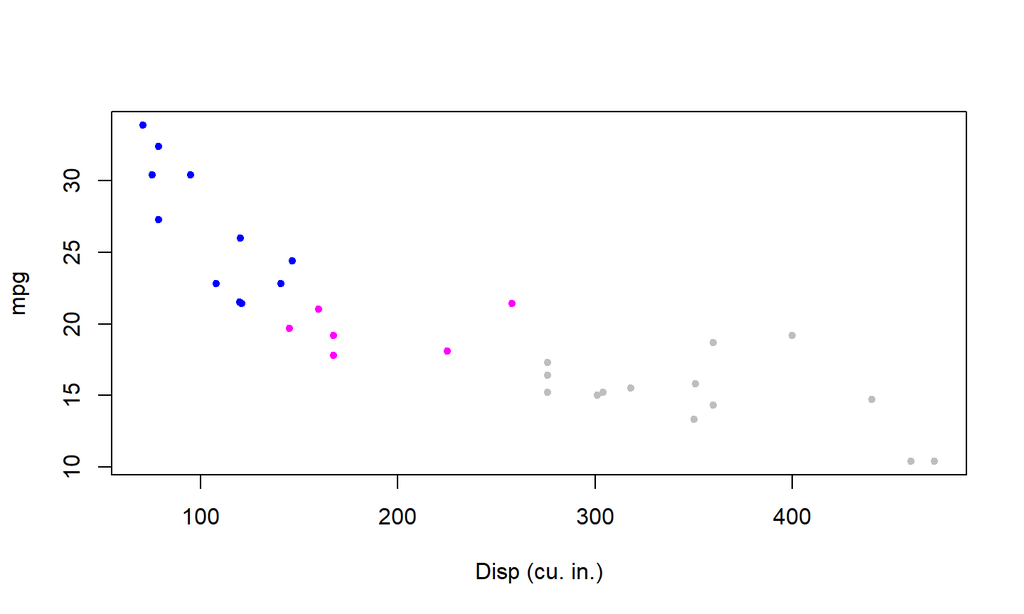

This is my caption

```r
plot(mtcars$disp, mtcars$mpg, col = mtcars$cyl, pch = 20, xlab = "Disp (cu. in.)", ylab = "mpg") # Plot the model
```

## Tables

- You can create raw markdown tables:

You type this:

```
First Header  | Second Header
------------- | -------------
Content Cell  | Content Cell
Content Cell  | Content Cell
```

It looks like this:

| First Header | Second Header |
| --- | --- |
| Content Cell | Content Cell |
| Content Cell | Content Cell |

## Tables

- The above was not great for tables that summarize data, instead, use `knitr::kable()`
- Using the `taxa_table.csv` file in the `CourseMaterials`

## Tables

```r
taxa_table <- read.csv("Data/taxa_table.csv") #Load the data

knitr::kable(taxa_table) # Create a table of the data
```

| Family | Genus | Species | Count | Surfers |
| --- | --- | --- | --- | --- |
| Pomacentridae | Hypsypops | rubicundus | 1 | 20 |
| Polyprionidae | Stereolepis | gigas | 2 | 18 |
| Scorpaenidae | Sebastes | hopkinsi | 30 | 10 |
| Scorpaenidae | Sebastes | paucispinis | 45 | 1 |
| Scorpaenidae | Pterois | volitans | 62 | 2 |
| Serranidae | Paralabrax | clathratus | 12 | 8 |
| Serranidae | Paralabrax | nebulifer | 15 | 12 |

## California's State Fish

[figure not shown]

Juvenile Garibaldi (*Hypsypops rubicundus*)

- October 15, 1995, Adopted as the California State Marine Fish

## Fancier tables with `kableExtra`

But scientific names (*Genus species*) are supposed to be in italics!

- Specify format by columns

```r
knitr::kable(taxa_table, format = "html") %>%
  kableExtra::kable_styling() %>%
  kableExtra::column_spec(column = 2, italic = T) %>% #specify column styles
  kableExtra::column_spec(column = 3, italic = T) %>%
  kableExtra::column_spec(column = 4, bold = T)
```

| Family | Genus | Species | Count | Surfers |
| --- | --- | --- | --- | --- |
| Pomacentridae | Hypsypops | rubicundus | 1 | 20 |
| Polyprionidae | Stereolepis | gigas | 2 | 18 |
| Scorpaenidae | Sebastes | hopkinsi | 30 | 10 |
| Scorpaenidae | Sebastes | paucispinis | 45 | 1 |
| Scorpaenidae | Pterois | volitans | 62 | 2 |
| Serranidae | Paralabrax | clathratus | 12 | 8 |
| Serranidae | Paralabrax | nebulifer | 15 | 12 |

## Fancier tables with `kableExtra`

- Collapse rows

```r
knitr::kable(taxa_table, format = "html") %>%
  kableExtra::kable_styling() %>%
  kableExtra::column_spec(column = 2, italic = T) %>% # Specify column styles
  kableExtra::column_spec(column = 3, italic = T) %>%
  kableExtra::column_spec(column = 4, bold = T) %>%
  kableExtra::collapse_rows(columns = c(1,2)) #collapse some rowws to delete obvious information
```

| Family | Genus | Species | Count | Surfers |
| --- | --- | --- | --- | --- |
| Pomacentridae | Hypsypops | rubicundus | 1 | 20 |
| Polyprionidae | Stereolepis | gigas | 2 | 18 |
| Scorpaenidae | Sebastes | hopkinsi | 30 | 10 |
|  |  | paucispinis | 45 | 1 |
|  | Pterois | volitans | 62 | 2 |
| Serranidae | Paralabrax | clathratus | 12 | 8 |
|  |  | nebulifer | 15 | 12 |

## If there is time

Should be less than ~7 minutes

- Create an html document:
  - Title
  - Subtitle
  - Author
  - Headers and subheader
  - A list with bullets
  - Text with old and itallics
  - 1 plot (nothing meaningful, invent something or use existing data)
  - 1 `knitr` + `kableExtra` table
- Extra:
  - Include an equation
  - Code doesn't show
  - Include at least 1 reference from the BibTex file

## Resources

- Intro to R Markdown:
  - [Tutorial](http://rmarkdown.rstudio.com/lesson-1.html)
- YAML options:
  - See [options for HTML](http://rmarkdown.rstudio.com/html_document_format.html)
  - See [options for PDF](http://rmarkdown.rstudio.com/pdf_document_format.html)
- References
  - [Citation style library](http://editor.citationstyles.org/about/)
  - Tyler Clavelle's [tutorial](https://tclavelle.github.io/blog/reference_tips/)
- Stargazer
  - Jake Russ' [cheatsheet](http://www.jakeruss.com/cheatsheets/stargazer/)
- kableExtra
  - [For HTML output](http://haozhu233.github.io/kableExtra/awesome_table_in_html.html)
  - [For PDF output](http://haozhu233.github.io/kableExtra/awesome_table_in_pdf.pdf)

## Resources

- [R Markdown from RStudio tutorial](http://rmarkdown.rstudio.com/lesson-1.html)

## Show and tell

## Show and tell

- `<div id="refs"></div>` to specify placement of references (*i.e.* when you are writing a manuscript)
- To add line numbers and double-spacing to your manuscript, add to the YAML:

```
header-includes:
- \usepackage{setspace}
- \doublespacing
- \usepackage{lineno}
- \linenumbers
```